# Reproduzierbare Forschung mit R und Quarto – Praktischer Teil

## Mehrere Abbildungen

- Wir können auch mehrere Abbildungen zusammen einfügen:

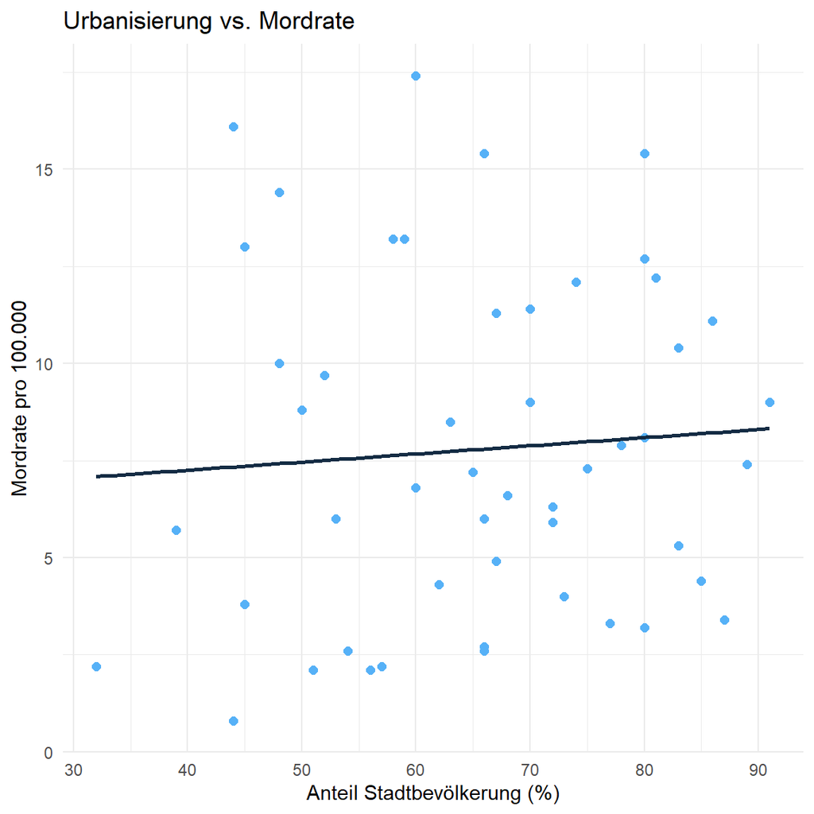

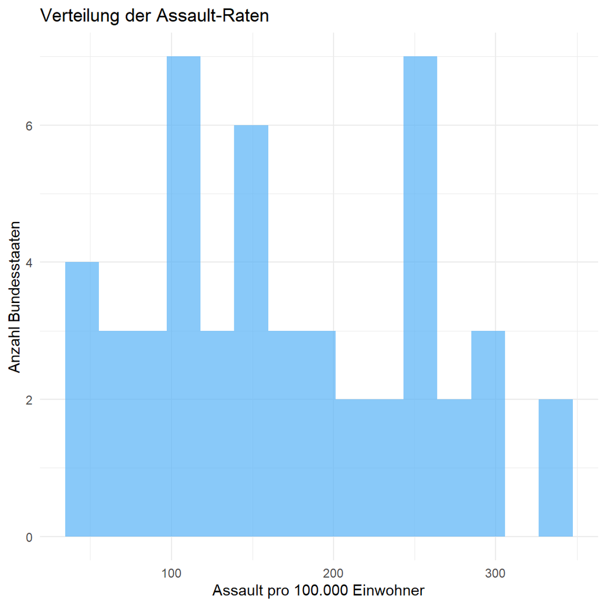

## Externe Grafiken

- Externe Bilder können mit Markdown-Syntax oder knitr::include_graphics() eingefügt werden:

**Markdown-Syntax:**

```markdown
![Bildbeschreibung](pfad/zum/bild.png){width=50%}
```

**R Code Chunk:**

```r
knitr::include_graphics("images/my_plot.png")
```

**Online-Bilder:**

```markdown
![R Logo](https://www.r-project.org/logo/Rlogo.png){width=200px}
```

## Tabellen

- Tabellen können mit vielen Paketen erstellt werden, z.B. `kable`, `gt`, `flextable` oder `pander`.
- Beispiel mit `kable`:

```r
data("USArrests")
library(knitr)
kable(head(USArrests), caption = "Erste 6 Zeilen des USArrests Datensatzes")
```

Erste 6 Zeilen des USArrests Datensatzes

|  | Murder | Assault | UrbanPop | Rape |
| --- | --- | --- | --- | --- |
| Alabama | 13.2 | 236 | 58 | 21.2 |
| Alaska | 10.0 | 263 | 48 | 44.5 |
| Arizona | 8.1 | 294 | 80 | 31.0 |
| Arkansas | 8.8 | 190 | 50 | 19.5 |
| California | 9.0 | 276 | 91 | 40.6 |
| Colorado | 7.9 | 204 | 78 | 38.7 |

## Tabellen-Export für Manuskripte

- Tabellen können in verschiedenen Formaten exportiert werden, z.B. LaTeX, HTML oder Word.
- Beispiel mit `flextable` für eine APA-konforme Tabelle:

```r
library(flextable)
tabelle <- flextable(head(USArrests))

tabelle |>
  save_as_docx("USArrests_table.docx", path = here::here("tables"))
```

## Übung 2

- Verwenden Sie entweder Ihr existierendes Quarto-Dokument oder laden Sie `aufgabe_02.qmd` herunter.
- Fügen Sie eine Abbildung hinzu, die den Zusammenhang zwischen “UrbanPop” und “Assault” im USArrests Datensatz zeigt.
  - Ändern Sie die Größe der Abbildung.
  - Optional: Speichern Sie die Abbildung und laden Sie als externes Bild ein.
- Fügen Sie eine Tabelle hinzu.
- Versuchen Sie, die Tabelle schöner zu formatieren.

## Referenzen

- Referenzen können mit BibTeX-Dateien eingebunden werden.
- Als Beispiel verwenden wir `referenzen.bib`. Dies müssen wir im YAML-Header angeben:

```yaml
bibliography: referenzen.bib
csl: apa.csl  # Optional: Style
```

- Ein Zitat kann dann so aussehen:
  - `[@wickham2016]` → (Wickham, 2016)
  - `@wickham2016` → Wickham (2016)
  - `[@wickham2016; @r2023]` → (Wickham, 2016; R Core Team, 2023)

## BibTeX Beispiel

Eine typische `referenzen.bib` Datei sieht so aus:

```
@book{wickham2016,
  title = {R for Data Science},
  author = {Hadley Wickham and Garrett Grolemund},
  year = {2016},
  publisher = {O'Reilly Media},
  isbn = {978-1491910399}
}

@manual{r2023,
  title = {R: A Language and Environment for Statistical Computing},
  author = {{R Core Team}},
  organization = {R Foundation for Statistical Computing},
  address = {Vienna, Austria},
  year = {2023},
  url = {https://www.R-project.org/}
}
```

## Verschiedene Zitierweisen

| Syntax | Ausgabe | Verwendung |
| --- | --- | --- |
| `[@autor2023]` | (Autor, 2023) | Normale Klammerzitate |
| `@autor2023` | Autor (2023) | Autor als Teil des Satzes |
| `[@autor2023, S. 15]` | (Autor, 2023, S. 15) | Mit Seitenzahl |
| `[-@autor2023]` | (2023) | Nur Jahr, ohne Autor |
| `[@autor2023; @autor2024]` | (Autor, 2023, 2024) | Mehrere Quellen |

## Referenzen hinzufügen

**Manuell in der BibTeX-Datei:** - Direkt in `referenzen.bib` editieren - Google Scholar: “Zitieren” → “BibTeX” kopieren (und DOI hinzufügen)

**Zotero Integration:** - Better BibTeX Plugin installieren - Auto-Export zu `.bib` Datei - Sync zwischen Zotero und Quarto

**RStudio Visual Editor:** - `Insert` → `Citation` - Automatisches Hinzufügen zur `.bib` Datei

## Literaturverzeichnis

- Wird automatisch am Ende des Dokuments eingefügt
- Nur zitierte Quellen werden angezeigt
- Anpassung der Position:

```markdown
# Literatur
::: {#refs}
:::

# Anhang
Weiterer Inhalt nach dem Literaturverzeichnis...
```

## Rechenintensive Chunks

- Teilweise möchten wir Code nicht ausführen, wenn das Dokument gerendert wird
  - z.B. bei rechenintensiven Operationen
  - Ausführung des Codes auf einem Server
  - oder bei Zufallsimulationen
  - oder wenn wir nur den Code zeigen wollen
- Beispiel:

```r
data("USArrests")

# Bootstrap durchführen, um Konfidenzintervall einer Regression zu schätzen
n_boot <- 1000
bootstrap_results <- numeric(n_boot)

# Warnung: Dieser Code dauert ca. 30 Sekunden!
system.time({
  for(i in 1:n_boot) {
    # Zufälliges Sampling mit Zurücklegen
    boot_sample <- sample(nrow(USArrests), replace = TRUE)
    boot_data <- USArrests[boot_sample, ]


    boot_model <- lm(Murder ~ UrbanPop, data = boot_data)
    # Extrahieren der Slope
    bootstrap_results[i] <- coef(boot_model)[2]
  }
})

# Konfidenzintervall berechnen
ci_lower <- quantile(bootstrap_results, 0.025)
ci_upper <- quantile(bootstrap_results, 0.975)
```

## Übung 3

- Arbeiten sie entweder in Ihrer existierenden Quarto- Datei weiter oder verwenden Sie `aufgabe_03.qmd`.
- Fügen Sie eine Referenz zu einem Buch oder Artikel hinzu, den Sie interessant finden.
- Lassen Sie das Literaturverzeichnis am Ende des Dokuments erscheinen.
- Führen Sie eine Regression auf den USArrests Datensatz durch und speichern Sie das Ergebnis. Sorgen Sie dafür, dass der Code nicht ausgeführt wird, wenn das Dokument gerendert wird.
- Optional: Versuchen Sie, das Dokument so zu formatieren, dass es möglichst nah an einen echten Artikel herankommt.

## Session Info

**R version 4.5.0 (2025-04-11 ucrt)**

**Platform:** x86_64-w64-mingw32/x64

**locale:** *LC_COLLATE=German_Germany.utf8*, *LC_CTYPE=German_Germany.utf8*, *LC_MONETARY=German_Germany.utf8*, *LC_NUMERIC=C* and *LC_TIME=German_Germany.utf8*

**attached base packages:** *stats*, *graphics*, *grDevices*, *utils*, *datasets*, *methods* and *base*

**other attached packages:** *knitr(v.1.50)* and *ggplot2(v.3.5.2.9001)*

**loaded via a namespace (and not attached):** *Matrix(v.1.7-3)*, *gtable(v.0.3.6)*, *jsonlite(v.2.0.0)*, *dplyr(v.1.1.4)*, *compiler(v.4.5.0)*, *tidyselect(v.1.2.1)*, *Rcpp(v.1.0.14)*, *dichromat(v.2.0-0.1)*, *splines(v.4.5.0)*, *scales(v.1.4.0)*, *yaml(v.2.3.10)*, *fastmap(v.1.2.0)*, *lattice(v.0.22-7)*, *R6(v.2.6.1)*, *labeling(v.0.4.3)*, *generics(v.0.1.3)*, *tibble(v.3.2.1)*, *pander(v.0.6.6)*, *pillar(v.1.10.2)*, *RColorBrewer(v.1.1-3)*, *rlang(v.1.1.6)*, *xfun(v.0.52)*, *S7(v.0.2.0)*, *cli(v.3.6.5)*, *withr(v.3.0.2)*, *magrittr(v.2.0.3)*, *mgcv(v.1.9-3)*, *digest(v.0.6.37)*, *grid(v.4.5.0)*, *lifecycle(v.1.0.4)*, *nlme(v.3.1-168)*, *vctrs(v.0.6.5)*, *evaluate(v.1.0.3)*, *glue(v.1.8.0)*, *farver(v.2.1.2)*, *rmarkdown(v.2.29)*, *tools(v.4.5.0)*, *pkgconfig(v.2.0.3)* and *htmltools(v.0.5.8.1)*

## Literatur

Wickham, H., M. Çetinkaya-Rundel, and G. Grolemund. 2023. *R for Data Science: Import, Tidy, Transform, Visualize, and Model Data*. O’Reilly Media.